# Supplementary File 5: EMS - metacommunity analysis

Diana Proctor

November 10, 2017

This is the FIFTH script used to generate the main figures for the the manuscript titled “A spatial gradient of bacterial diversity in the human oral cavity shaped by salivary flow”

This script and associated data are provided via (c) by Diana M Proctor, Julia A. Fukuyama, Susan P. Holmes, and David A. Relman. These data are licensed under the Creative Commons Attribution-ShareAlike 4.0 International License (CC-BY-CA).

# Let’s take a look at coherence

From the package authors (?Coherence): This function determines the number of embedded absences in an interaction matrix, and compares this value against null simulated matrices. Species ranges should be coherent along the ordination axis, as this axis represents a latent environmental gradient. A negative value of coherence (empirical matrix has more embedded absences than null matrices) indicates a ‘checkerboard’ pattern (Leibold & Mikkelson 2002). Nonsignificance has been historically interpreted as being indicative of a ‘random’ pattern, though this may be seen as accepting the null hypothesis, as nonsignificance cannot be used to infer a process.

The default method argument is ‘r1’, which maintains the species richness of a site (row totals) and fills species ranges (columns) based on their marginal probabilities.

# output

A vector containing the number of embedded absences (embAbs), z-score (z), p-value (pval), mean (simulatedMean) and variance (simulatedVariance) of simulations, and null model randomization method (method).

# subset on day 1 samples for aim 1 subjects

aim1 = subset_samples(supra, Aim==“SA1”) aim1 = subset_samples(aim1, Day==“1”) aim1 = prune_taxa(taxa_sums(aim1) > 0, aim1) aim1 = prune_samples(sample_sums(aim1) > 0, aim1)

subs = levels(sample_data(aim1)$Subject) library(metacom) Coherence_Holder <- vector(‘list’, length(subs)) names(Coherence_Holder)

### Aim 1 subject, 1- did this for 1-101, 1-102, and 1-107

s1 = subset_samples(aim1, Subject==subs[[1]]) s1 = prune_taxa(taxa_sums(s1) > 0, s1) s1 = prune_samples(sample_sums(s1) > 0, s1) otus = data.frame(otu_table(s1)) otus.pa = decostand(otus, “pa”) coh = Coherence(otus.pa, method=“r1”, sims=1000, scores=1, order=TRUE, allowEmpty = FALSE, binary=TRUE, verbose=TRUE, seed=89) Coherence_Holder[[1]] = coh save.image(file=“~/Dropbox/Coherence_holder1.Rdata”)

### Compute coherence on the sums across aim 1

hab = merge_samples(aim1, “Habitat”) hab = prune_taxa(taxa_sums(hab) > 0, hab) hab = prune_samples(sample_sums(hab) > 0, hab) otus = data.frame(otu_table(hab)) otus.pa = decostand(otus, “pa”) coh = Coherence(otus.pa, method=“r1”, sims=1000, scores=1, order=TRUE, allowEmpty = FALSE, binary=TRUE, verbose=TRUE, seed=89) Coherence_Holder[[1]] = coh save.image(file=“~/Dropbox/a1_coherence2.Rdata”)

### Compuete coherence on the sums across aim 3

hab = merge_samples(aim3, “Habitat”) hab = prune_taxa(taxa_sums(hab) > 0, hab) hab = prune_samples(sample_sums(hab) > 0, hab) otus = data.frame(otu_table(hab)) otus.pa = decostand(otus, “pa”) a3_sum_coh = Coherence(otus.pa, method=“r1”, sims=1000, scores=1, order=TRUE, allowEmpty = FALSE, binary=TRUE, verbose=TRUE, seed=89) save.image(file=“~/Desktop/EMS/a1_coherence2.Rdata”)

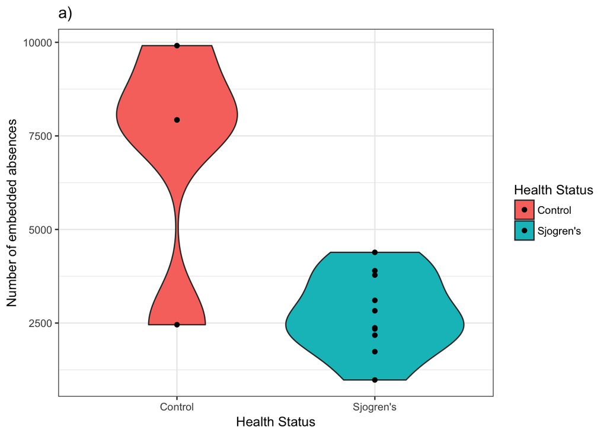

```r
library(ggplot2);library(metacom);library(phyloseq)
load('~/Desktop/EMS/a1_coherence2.Rdata')

#get the aim 3 sum
a3_sum = do.call("cbind", a3_sum_coh)
a3_sum = data.frame(as.matrix(a3_sum))
a3_sum$Aim = "SA3"
a3_sum$Subject = "sum"

#get the aim 3 subjects
load("~/Desktop/EMS/aim3_coherence.Rdata")
aim3_coh = do.call("rbind", a3_CorrHolder)
names = rownames(aim3_coh)
aim3_coh = data.frame(as.matrix(aim3_coh))
aim3.df = data.frame(matrix(unlist(aim3_coh), nrow=10, byrow = FALSE))
colnames(aim3.df)= c("embAbs", "z", "pval", "simulatedMean", "simulatedVariance", "method")
aim3.df$Aim = "SA3"
aim3.df$Subject = names

#combine
aim3.df2 = rbind(aim3.df, a3_sum)
aim3.df2 = data.frame(aim3.df2)

#get the aim 1 data from the summed subjects
load('~/Desktop/EMS/a1_coherence2.Rdata')
aim1_coh = do.call("cbind", a1_sum_coh)
aim1_coh = data.frame(as.matrix(aim1_coh))
aim1.df = data.frame(matrix(unlist(aim1_coh), nrow=1, byrow = TRUE))
colnames(aim1.df)= c("embAbs", "z", "pval", "simulatedMean", "simulatedVariance", "method")
aim1.df$Aim = "SA1"
aim1.df$Subject = "sums"

#read in the subject specific coherence estimages
t=readRDS(file="~/Desktop/EMS/aim1_CorrHolder_first_three.RDS")
t1 = do.call("rbind", t)
t1 = data.frame(matrix(unlist(t1), nrow=2, byrow = TRUE))
colnames(t1)= c("embAbs", "z", "pval", "simulatedMean", "simulatedVariance", "method")
t1$Aim = "SA1"
t1$Subject = c("1-101", "1-102")

load('~/Desktop/EMS/Coherence_holder.Rdata')
t2 = do.call("cbind", Coherence_Holder)
t2 = data.frame(matrix(unlist(t2), nrow=1, byrow = FALSE))
colnames(t2)= c("embAbs", "z", "pval", "simulatedMean", "simulatedVariance", "method")
t2$Aim = "SA1"
t2$Subject = "1-107"


#combine
coh.df = data.frame(rbind(aim1.df, t1, t2))
coherence.df = data.frame(rbind(coh.df, aim3.df))
coherence.df$embAbs = as.numeric(as.character(coherence.df$embAbs))
coherence.df$simulatedMean = as.numeric(as.character(coherence.df$simulatedMean))
coherence.df$Aim = ifelse(coherence.df$Aim=="SA1", "Control", "Sjogren's")

#plot the coherence estimates
p1=ggplot(coherence.df, aes(Aim, embAbs,fill=Aim)) + theme_bw() +geom_violin() + ggtitle(("a)"))  + geom_point() + guides(fill=guide_legend(title="Health Status")) + xlab("Health Status") + ylab("Number of embedded absences")
p1
```

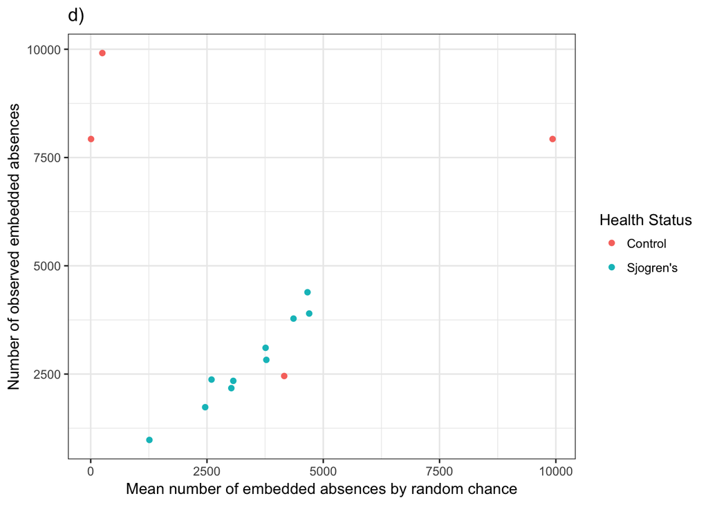

```r
p4=ggplot(coherence.df, aes(simulatedMean, embAbs,color=Aim)) + theme_bw()  +ggtitle(("d)"))  + geom_point()+ guides(color=guide_legend(title="Health Status")) + xlab("Mean number of embedded absences by random chance") + ylab("Number of observed embedded absences")
p4
```

```r
print(coherence.df)
```

```
##      embAbs                z                 pval simulatedMean
## 1  7927.000 5.85474012874506  4.7775646260245e-09   9930.214000
## 2  7927.000             7560     5.80669077471675      7.367885
## 3  9912.026         9406.289     341.851508374291    250.586031
## 4  2455.000 12.4302822132358  1.7900129761121e-35   4160.360000
## 5  3898.000 3.59262481186318  0.00032736376840557   4697.471000
## 6  3106.000 4.40511121620193 1.05729618932159e-05   3760.249000
## 7  2373.000 1.71028488604744   0.0872132052443876   2597.669000
## 8  2175.000 5.40027386002655 6.65392407247136e-08   3023.405000
## 9  2828.000 9.45177401323934 3.33136012389862e-21   3776.278000
## 10 1735.000 8.36001686915019 6.27092891424083e-17   2461.481000
## 11 2343.000 4.31538484188834 1.59325092890612e-05   3065.529000
## 12 4389.000 1.61808369884489     0.10564456104593   4661.168000
## 13 3781.000 4.74648668376876 2.06980344352359e-06   4360.260000
## 14  979.000 3.43896168143262 0.000583949883117317   1262.008000
##     simulatedVariance               method       Aim Subject
## 1    342.152504799454                   r1   Control    sums
## 2  6.371966118828e-09 1.73356523931619e-13   Control   1-101
## 3                  r1                   r1   Control   1-102
## 4    137.193988901083                   r1   Control   1-107
## 5    222.531169233167                   r1 Sjogren's   3-301
## 6    148.520427269505                   r1 Sjogren's   3-302
## 7    131.363494955055                   r1 Sjogren's   3-303
## 8    157.104069532472                   r1 Sjogren's   3-304
## 9    100.328044097513                   r1 Sjogren's   3-305
## 10   86.8994657990264                   r1 Sjogren's   3-306
## 11   167.430953778814                   r1 Sjogren's   3-307
## 12    168.20390700079                   r1 Sjogren's   3-308
## 13   122.039739831327                   r1 Sjogren's   3-309
## 14   82.2946069821002                   r1 Sjogren's   3-310
```

# Look at turnover

- we see that the observed turnover is correlated with the simulated mean turnover
- we also see that turnover is reduced (both simulated mean and the observed turnover) in the SS compared to healthy controls
- notably, one healthy control (1-107) has a turnover rating that is comparable to the aim 3 subject; will want to see if this subject has a lower relative salivary flow rate or what other similarity this subject may have with the SS group

### from the package author

If the ‘community’ perspective is desired, simply transpose the matrix before analysis using the transpose function (‘t()’), but make sure you understand the implications of this action, as the interpretation of the output changes dramatically.

‘method’ is an argument handed to functions in the ‘vegan’ package. Leibold & Mikkelson advocated the use of equiprobable rows and columns (provided that rows and columns had at least one entry). This method is called ‘r00’. Methods maintaining row (site) frequencies include ‘r0’,‘r1’ & ‘r2’. The default method argument is ‘r1’, which maintains the species richness of a site (row totals) and fills species ranges (columns) based on their marginal probabilities. Arguably the most conservative null algorithm is the fixed row - fixed column total null, which is implemented as ‘fixedfixed’. See the help file for ‘commsimulator’ or Wright et al. 1998 for more information.

If ‘order’ is FALSE, the interaction matrix is not ordinated, allowing the user to order the matrix based on site characteristics or other biologically relevant characteristics.

This function can either be used as a standalone, or can be used through the ‘metacommunity()’ function, which determines all 3 elements of metacommunity structure (coherence, boundary clumping, & turnover) (Leibold & Mikkelson 2002). The turnover metric used here is equivalent to the number of checkerboard units community with species ranges (range perspective) filled in

*Value* A data.frame containing the test statistic (turnover), z-value (z), p-value (pval), mean (simulatedMean) and variance (simulatedVariance) of simulations, and randomization method (method)

aim1 = subset_samples(supra, Aim==“SA1”) aim1 = prune_taxa(taxa_sums(aim1) > 0, aim1) aim1 = prune_samples(sample_sums(aim1) > 0, aim1) subs = levels(sample_data(aim1)$Subject)

a1_Turnover <- vector(‘list’, length(subs)) names(a1_Turnover) = subs for(i in 1:length(subs)){ s1 = subset_samples(aim1, Subject==subs[[i]]) s1 = prune_taxa(taxa_sums(s1) > 0, s1) s1 = prune_samples(sample_sums(s1) > 0, s1) hab = merge_samples(s1, “Habitat”) otus = data.frame(otu_table(hab)) otus.pa = decostand(otus, “pa”) turn.out = Turnover(otus.pa, method = “r1”, sims = 1000, scores = 1, order = TRUE, allowEmpty = FALSE, binary = TRUE, verbose = FALSE) a1_Turnover[[i]] = turn.out

} a1_Turnover

### Aim 3

aim3 = subset_samples(supra, Aim==“SA3”) aim3 = prune_taxa(taxa_sums(aim3) > 0, aim3) aim3 = prune_samples(sample_sums(aim3) > 0, aim3) subs = levels(sample_data(aim3)$Subject)

a3_Turnover<- vector(‘list’, length(subs)) names(a3_Turnover) = subs for(i in 1:length(subs)){ s3 = subset_samples(aim3, Subject==subs[[i]]) s3 = prune_taxa(taxa_sums(s3) > 0, s3) s3 = prune_samples(sample_sums(s3) > 0, s3) hab = merge_samples(s3, “Habitat”) otus = data.frame(otu_table(hab)) otus.pa = decostand(otus, “pa”) turn.out = Turnover(otus.pa, method = “r1”, sims = 1000, scores = 1, order = TRUE, allowEmpty = FALSE, binary = TRUE, verbose = FALSE) a3_Turnover[[i]] <- turn.out

} a3_Turnover

##### Buccal

aim1_buccal = subset_samples(aim1, Tooth_Aspect==“Buccal”) aim1_buccal = prune_taxa(taxa_sums(aim1_buccal) > 0, aim1_buccal) aim1_buccal = prune_samples(sample_sums(aim1_buccal) > 0, aim1_buccal) subs = levels(sample_data(aim1_buccal)$Subject)

a1_buccal_Turnover <- vector(‘list’, length(subs)) names(a1_buccal_Turnover) = subs for(i in 1:length(subs)){ s1 = subset_samples(aim1, Subject==subs[[i]]) s1 = prune_taxa(taxa_sums(s1) > 0, s1) s1 = prune_samples(sample_sums(s1) > 0, s1) hab = merge_samples(s1, “Habitat”) otus = data.frame(otu_table(hab)) otus.pa = decostand(otus, “pa”) turn.out = Turnover(otus.pa, method = “r1”, sims = 1000, scores = 1, order = TRUE, allowEmpty = FALSE, binary = TRUE, verbose = FALSE) a1_buccal_Turnover[[i]] = turn.out

} a1_buccal_Turnover

### Aim 3

aim3_buccal = subset_samples(aim3, Tooth_Aspect==“Buccal”) aim3_buccal = prune_taxa(taxa_sums(aim3_buccal) > 0, aim3_buccal) aim3_buccal = prune_samples(sample_sums(aim3_buccal) > 0, aim3_buccal) subs = levels(sample_data(aim3_buccal)$Subject)

a3_buccal_Turnover <- vector(‘list’, length(subs)) names(a3_buccal_Turnover) = subs for(i in 1:length(subs)){ s1 = subset_samples(aim3, Subject==subs[[i]]) s1 = prune_taxa(taxa_sums(s1) > 0, s1) s1 = prune_samples(sample_sums(s1) > 0, s1) hab = merge_samples(s1, “Habitat”) otus = data.frame(otu_table(hab)) otus.pa = decostand(otus, “pa”) turn.out = Turnover(otus.pa, method = “r1”, sims = 1000, scores = 1, order = TRUE, allowEmpty = FALSE, binary = TRUE, verbose = FALSE) a3_buccal_Turnover[[i]] = turn.out } a3_buccal_Turnover

##### lingual

aim1_lingual = subset_samples(aim1, Tooth_Aspect==“Lingual”) aim1_lingual = prune_taxa(taxa_sums(aim1_lingual) > 0, aim1_lingual) aim1_lingual = prune_samples(sample_sums(aim1_lingual) > 0, aim1_lingual) subs = levels(sample_data(aim1_lingual)$Subject)

a1_lingual_Turnover <- vector(‘list’, length(subs)) names(a1_lingual_Turnover) = subs for(i in 1:length(subs)){ s1 = subset_samples(aim1, Subject==subs[[i]]) s1 = prune_taxa(taxa_sums(s1) > 0, s1) s1 = prune_samples(sample_sums(s1) > 0, s1) hab = merge_samples(s1, “Habitat”) otus = data.frame(otu_table(hab)) otus.pa = decostand(otus, “pa”) turn.out = Turnover(otus.pa, method = “r1”, sims = 1000, scores = 1, order = TRUE, allowEmpty = FALSE, binary = TRUE, verbose = FALSE) a1_lingual_Turnover[[i]] = turn.out

} a1_lingual_Turnover

### Aim 3

aim3_lingual = subset_samples(aim3, Tooth_Aspect==“Lingual”) aim3_lingual = prune_taxa(taxa_sums(aim3_lingual) > 0, aim3_lingual) aim3_lingual = prune_samples(sample_sums(aim3_lingual) > 0, aim3_lingual) subs = levels(sample_data(aim3_lingual)$Subject)

a3_lingual_Turnover <- vector(‘list’, length(subs)) names(a3_lingual_Turnover) = subs for(i in 1:length(subs)){ s1 = subset_samples(aim3, Subject==subs[[i]]) s1 = prune_taxa(taxa_sums(s1) > 0, s1) s1 = prune_samples(sample_sums(s1) > 0, s1) hab = merge_samples(s1, “Habitat”) otus = data.frame(otu_table(hab)) otus.pa = decostand(otus, “pa”) turn.out = Turnover(otus.pa, method = “r1”, sims = 1000, scores = 1, order = TRUE, allowEmpty = FALSE, binary = TRUE, verbose = FALSE) a3_lingual_Turnover[[i]] = turn.out } a3_lingual_Turnover

save.image(“turnover_v3.1.Rdata”)

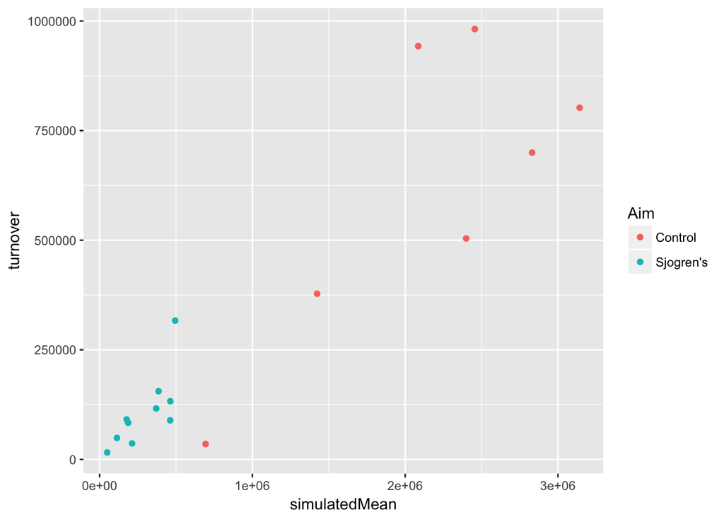

```r
load("~/Desktop/EMS/turnover_v3.1.Rdata")

library(phyloseq);library(reshape2);library(stringr)
#get all the aim 1 turnover stats into a single data.frame - lingual
a1turn.df = df <- data.frame(do.call("rbind", a1_Turnover))
a1turn.df$diff= a1turn.df$turnover-a1turn.df$simulatedMean
a1turn.df$Subject = rownames(a1turn.df)
a1turn.df$Aim = "SA1"

#get all the aim 3 turnover stats into a single data frame = Buccal
a3turn.df = df <- data.frame(do.call("rbind", a3_Turnover))
a3turn.df$diff= a3turn.df$turnover-a3turn.df$simulatedMean
a3turn.df$Subject = rownames(a3turn.df)
a3turn.df$Aim = "SA3"


#combine the aim1 and aim 3 turnover stats
turnover.df = rbind(a1turn.df, a3turn.df)
turnover.df$Aim = ifelse(turnover.df$Aim=="SA1", "Control", "Sjogren's")

#plot the turnover stats
ggplot(turnover.df, aes(simulatedMean, turnover, color=Aim)) + geom_point()
```

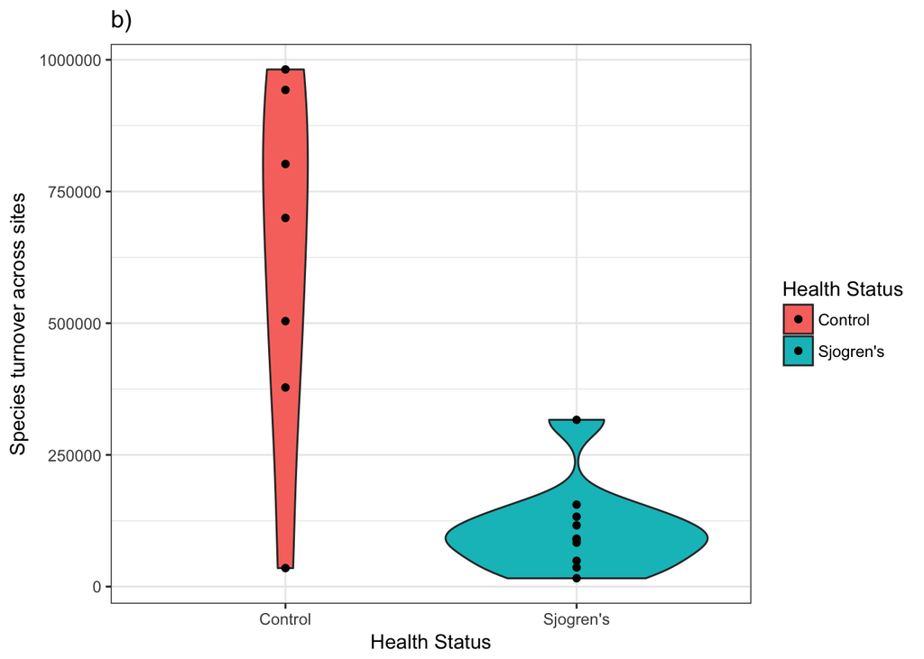

```r
#which aim 1 subject has turnover like aim 3?
p2 = ggplot(turnover.df, aes(Aim, turnover,fill=Aim)) + theme_bw() +geom_violin() +ggtitle(("b)"))  + geom_point()+ guides(fill=guide_legend(title="Health Status"))+ xlab("Health Status") + ylab("Species turnover across sites")
p2
```

```r
p5 = ggplot(turnover.df, aes(simulatedMean, turnover,color=Aim)) + theme_bw()  +ggtitle(("e)"))  + geom_point()+ guides(color=guide_legend(title="Health Status")) + xlab("Mean turnover based on a random model") + ylab("Observed species turnover across teeth")
```

### from the package developer

This statistic is not based on randomization methods, so the function only requires a presence-absence interaction matrix and two arguments regarding the ordination of the empirical matrix.

The default is the range perspective, meaning that the analyses of boundary clumping and species turnover compare the distribution of species among sites. If the ’community’ perspective is desired, transpose the matrix before analysis using the transpose function (’t()’). However, the author cau- tions against misinterpretation of the community perspective, as the biological meaning of turnover and boundary clumping differ between perspectives.

Boundary clumping, quantified by the Morisita’s index, is a measure of the degree to which species range boundaries overlap. This measure, and species turnover, cannot be interpreted unless the network is significantly coherent (see ’Coherence()’).

If ’order’ is FALSE, the interaction matrix is not ordinated, allowing the user to order the matrix based on site characteristics or other biologically relevant characteristics.

’BoundaryClump’ returns a data frame containing the calculated Morisita’s index (’index’), the corresponding p-value (’P’), and the degrees of freedom (’df’). The p-value is based on a chi-squared test comparing the Morisita’s index to a value of 1. If the Morisita’s index is less than 1, a left-tailed test is performed (less clumping than expected by chance). If the Morisita’s index is greater than 1, a right-tailed test is performed (more clumping han expected by chance)

#### Calculate Boundary clumping

‘BoundaryClump’ calculates the Morisita’s Index (Morisita 1962) for presence-absence interaction matrices, using a chi-squared test to assess significance.

This statistic is not based on randomization methods, so the function only requires a presence-absence interaction matrix and two arguments regarding the ordination of the empirical matrix.

The default is the range perspective, meaning that the analyses of boundary clumping and species boundary compare the distribution of species among sites. If the ‘community’ perspective is desired, transpose the matrix before analysis using the transpose function (‘t()’). However, the author cautions against misinterpretation of the community perspective, as the biological meaning of boundary and boundary clumping differ between perspectives.

Boundary clumping, quantified by the Morisita’s index, is a measure of the degree to which species range boundaries overlap. This measure, and species boundary, cannot be interpreted unless the network is significantly coherent (see ‘Coherence()’).

If ‘order’ is FALSE, the interaction matrix is not ordinated, allowing the user to order the matrix based on site characteristics or other biologically relevant characteristics.

# Output

‘BoundaryClump’ returns a data frame containing the calculated Morisita’s index (‘index’), the corresponding p-value (‘P’), and the degrees of freedom (‘df’).

The p-value is based on a chi-squared test comparing the Morisita’s index to a value of 1. If the Morisita’s index is less than 1, a left-tailed test is performed (less clumping than expected by chance).

If the Morisita’s index is greater than 1, a right-tailed test is performed (more clumping han expected by chance)

##### clumping

aim1 = subset_samples(supra, Aim==“SA1”) aim1 = subset_samples(aim1, Day==“1”) subs = levels(sample_data(aim1)$Subject)

a1_boundary <- vector(‘list’, length(subs)) names(a1_boundary) = subs

for(i in 1:length(subs)){ s1 = subset_samples(aim1, Subject==subs[[i]]) s1 = prune_taxa(taxa_sums(s1) > 0, s1) s1 = prune_samples(sample_sums(s1) > 0, s1) otus = data.frame(otu_table(s1)) otus.pa = decostand(otus, “pa”) boucl.pa = BoundaryClump(otus.pa, order = TRUE, scores = 1, binary = TRUE, fill = TRUE) a1_boundary[[i]] = boucl.pa

} a1_boundary

### Aim 3

aim3 = subset_samples(supra, Aim==“SA3”) aim3 = prune_taxa(taxa_sums(aim3) > 0, aim3) aim3 = prune_samples(sample_sums(aim3) > 0, aim3) subs = levels(sample_data(aim3)$Subject)

a3_boundary <- vector(‘list’, length(subs)) names(a3_boundary) = subs for(i in 1:length(subs)){ s1 = subset_samples(aim3, Subject==subs[[i]]) s1 = prune_taxa(taxa_sums(s1) > 0, s1) s1 = prune_samples(sample_sums(s1) > 0, s1) otus = data.frame(otu_table(s1)) otus.pa = decostand(otus, “pa”) boucl.pa = BoundaryClump(otus.pa, order = TRUE, scores = 1, binary = TRUE, fill = TRUE) a3_boundary[[i]] = boucl.pa } a3_boundary save.image(“~/Desktop/EMS/clumping_v4.0.Rdata”)

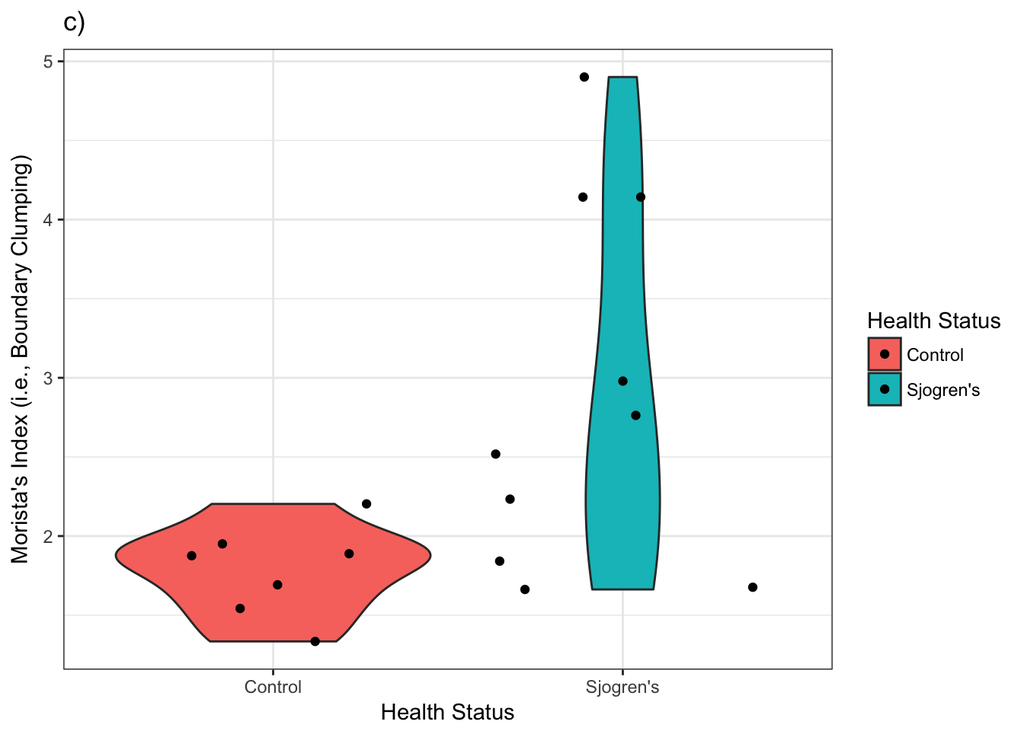

```r
load("~/Desktop/EMS/clumping_v4.0.Rdata")
#deal with aim 1
a1 = do.call("rbind", a1_boundary)
a1$Subject = rownames(a1)
a1$Aim = "SA1"


#deal with aim 3
a3 = do.call("rbind", a3_boundary)
a3$Subject = rownames(a3)
a3$Aim = "SA3"


#combind
boundary.df = rbind(a1, a3)
boundary.df$Aim = ifelse(boundary.df$Aim=="SA1", "Control", "Sjogren's")

#let's take a look at the boundary clumping stats
p3=ggplot(boundary.df, aes(Aim, index, fill=Aim)) + geom_violin() + theme_bw()+ geom_jitter() + ggtitle(("c)"))+ guides(fill=guide_legend(title="Health Status"))+ xlab("Health Status") + ylab("Morista's Index (i.e., Boundary Clumping)")
p3
```

### Since these factors seem to depend on the size of the matrix, get the size of the samples and the size of taxa for each data.frame

- note that the two control samples that have fewer taxa and samples belong to the pilot (p1-8, and p1-9)

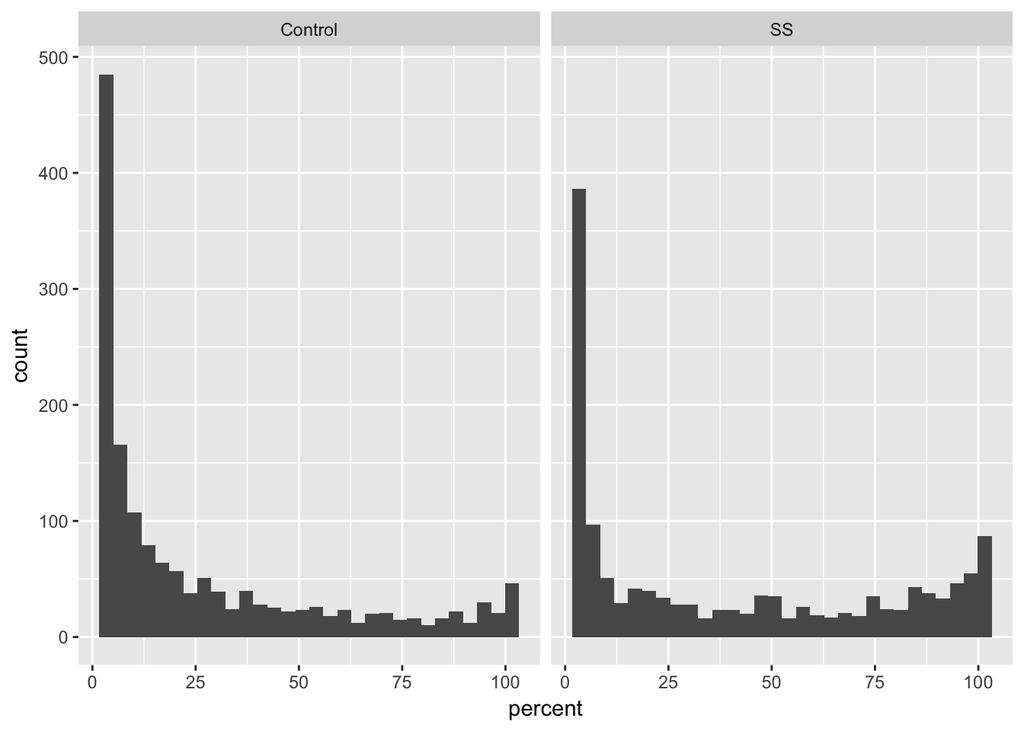

```r
#what is the size of the data.table for each data matrix
subs = levels(as.factor(sample_data(supra)$Subject))[1:17]
size_Holder <- vector('list', length(subs))
names(size_Holder) = subs
site_holder <- vector('list', length(subs))
for(i in 1:length(subs)){
  s1 = subset_samples(supra, Subject==subs[[i]])
  s1 = subset_samples(s1, Day=="1")
  s1 = prune_taxa(taxa_sums(s1) > 0, s1)
  s1 = prune_samples(sample_sums(s1) > 0, s1)
  df = data.frame(nsamples(s1), ntaxa(s1), subs[[i]])
  size_Holder[[i]] = df
  s1 = merge_samples(s1, "Habitat")
  fm = data.frame(tax_table(s1))$Highest.Rank
  taxa_names(s1) = fm
  otus = data.frame(otu_table(s1))
  otus.pa = decostand(otus, "pa")
  foo = data.frame(colSums(otus.pa))
  foo$Subject = subs[[i]]
  foo$nsites = length(levels(as.factor(sample_data(s1)$Habitat)))
  colnames(foo) = c("N.sites", "Subject", "Total")
  site_holder[[i]] = foo
}

df1 = do.call("rbind", site_holder)
df1$percent = 100*(df1$N.sites/df1$Total)
foo = colsplit(df1$Subject, "-", c("Aim", "Junk"))
foo$Aim = ifelse(foo$Aim==1, "Control", "SS")
df1$Aim = foo$Aim
ggplot(df1, aes(percent)) + geom_histogram() + facet_wrap(~Aim)
```

### Make a single plot with coherence, turnover and clumping in one plot

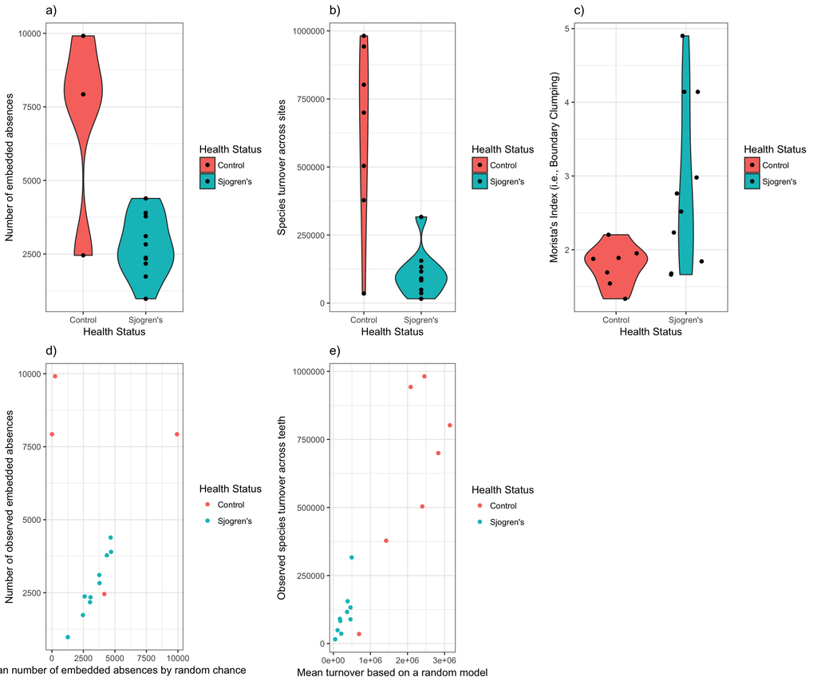

```r
library(gridExtra)
grid.arrange(p1, p2, p3, p4, p5, ncol=3)
```

```r
ggsave(grid.arrange(p1, p2, p3, p4, p5, ncol=3), file="~/Dropbox/Figures_20170617/Revised/FinalFigures/FigureS14.png",  width = 11, height = 8.5, units ="in",dpi = 300)
```